# Assignment #1

Warren Jodjana, Environmental Data Science @UIUC

9/8/2022

## Overview

In this assignment, we’ll explore a dataset of environmental features in the City of Chicago. Along the way, you’ll hone in on key themes learned from the first three weeks of our class. You’ll specifically review:

- Data Inspection
- Basic Mapping in R
- Attribute Queries
- Aggregating Data

You will be on your way to mastering the basics of `sf`, `tmap`, and basics of the `tidyverse`. It’s helpful if you’ve read through Chapter 3 on *Attribute Data Operations* in our course textbook, [Geocomputation in R](https://geocompr.robinlovelace.net/).

This assignment uses the *Chives* dataset from chichives.com. *ChiVes* is a collaborative project that integrates and visualizes data; a handful of key metrics―tree cover, air pollution estimates, heat island effects, traffic volumes, and social vulnerability index― help to reveal where in the city people face particular challenges as we work towards a healthier Chicago. You will need to review the [Data](https://chichives.com/data) page to understand the variable names and definitions to complete this assignment.

## Environment Setup

Download and open the course files (including the **.geojson** file and this **RMarkdown** file) on your system, or RStudio Cloud environment. Open the RmD file in RStudio. If you haven’t already, set your working directory.

```r
setwd("~/Documents/R/GGIS 224 (Environmental Data Science)/assignment-1")
```

Next, load up all the libraries needed for this assignment.

```r
library(sf)
library(spData)
library(tidyverse)
library(tmap)
```

Now you’re ready to load in the data. Make sure you’ve loaded the geojson in the same file directory as your RmD document.

Use the `sf` library function `st_read` to read in the geojson file. This spatial dataset was downloaded directly from *Chives*.

```r
chives <- st_read("chives-data.geojson")
```

## Explore Data

Over the past few weeks, we’ve been reading about, coding through examples of, and practicing attribute data wrangling. First we need to inspect and examine the data carefully, looking for interesting trends.

Use the `head()` function to inspect the data. (Uncomment on your own machine.) There are many other functions to use, if you prefer, like `glimpse`.

```r
head(chives)
```

```
## Simple feature collection with 6 features and 41 fields
## Geometry type: MULTIPOLYGON
## Dimension:     XY
## Bounding box:  xmin: -87.70465 ymin: 41.7943 xmax: -87.63535 ymax: 41.85934
## Geodetic CRS:  WGS 84
##         geoid simpson specCt uniqSp     ndvi acs_population svi_pecentile
## 1 17031291600   0.667      3      3 0.192543            976          63.9
## 2 17031580200   0.500      2      2 0.226763           3784          80.4
## 3 17031590500   0.973     78     52 0.405935           1842          80.7
## 4 17031590700   0.667      3      3 0.188116           3393          81.1
## 5 17031610400      NA     NA     NA 0.210973           1981          93.2
## 6 17031843800   0.667      3      3 0.247428           1482          82.6
##   trees_n trees_area trees_den trees_crown_den zip_code asthma_5yr_avg
## 1     453      25969  0.002056            11.8    60608          158.5
## 2    1588      93486  0.002176            12.8    60632          168.0
```

[output cut: 46 more lines]

How many census tracts do we have in this dataset? Use the `dim()` function to check.

```r
dim(chives)
```

```
## [1] 801  42
```

There are 801 rows, or census tracts, and 42 columns, or field attributes in this dataset.

Let’s quickly map an interesting variable in our dataset using `tmap`. We’ll explore the `tree_crown_den` attribute, which shows us the proportion of a census tract covered by tree crowns, as measured from LiDar data in 2010. Review the *Chives* website to learn more about this variable.

In this map we’ll use quantile breaks to classify the variable of interest; a red-yellow-green diverging color palette; and will also rename the variable in the legend for easier viewing.

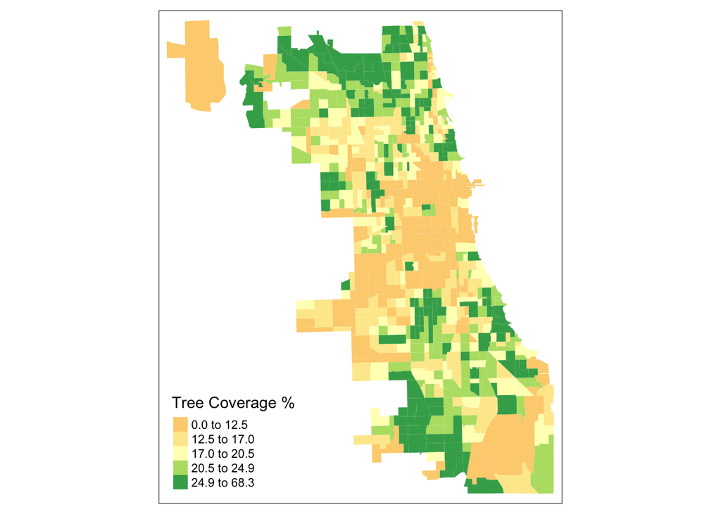

```r
tm_shape(chives) + tm_fill("trees_crown_den",
                           style = "quantile",
                           palette = "RdYlGn",
                           title = "Tree Coverage %")
```

Let’s explore data breaks further. Here’s one way of selecting all census tracts that have less than 10% of its area covered by trees:

```r
fewTrees <- chives %>%
  filter(trees_crown_den < 10)

head(fewTrees)
```

```
## Simple feature collection with 6 features and 41 fields
## Geometry type: MULTIPOLYGON
## Dimension:     XY
## Bounding box:  xmin: -87.94025 ymin: 41.80189 xmax: -87.62589 ymax: 42.00717
## Geodetic CRS:  WGS 84
##         geoid simpson specCt uniqSp     ndvi acs_population svi_pecentile
## 1 17031590700   0.667      3      3 0.188116           3393          81.1
## 2 17031610400      NA     NA     NA 0.210973           1981          93.2
## 3 17031381700   0.500      2      2       NA              0           0.0
## 4 17031030701   0.750      4      4 0.165450           1712          82.7
## 5 17031030702      NA     NA     NA 0.113273           2252          48.0
## 6 17031980000   0.945     20     19       NA              0           0.0
##   trees_n trees_area trees_den trees_crown_den zip_code asthma_5yr_avg
## 1    1330      68804  0.001529             7.9    60609         195.50
## 2     339      15797  0.002077             9.7    60609         195.50
```

[output cut: 46 more lines]

82 features were selected, meaning 82 out of all census tracts in the city have less than 10% of their areas covered by trees.

### Question 1

What’s another way to do this (ie. query your data)? Use a different selection option based on your readings and practice. The end output also identify tracts with less than 10% areas covered by trees.

```r
fewTrees2 <- subset(chives, trees_crown_den < 10)

head(fewTrees2)
```

```
## Simple feature collection with 6 features and 41 fields
## Geometry type: MULTIPOLYGON
## Dimension:     XY
## Bounding box:  xmin: -87.94025 ymin: 41.80189 xmax: -87.62589 ymax: 42.00717
## Geodetic CRS:  WGS 84
##          geoid simpson specCt uniqSp     ndvi acs_population svi_pecentile
## 4  17031590700   0.667      3      3 0.188116           3393          81.1
## 5  17031610400      NA     NA     NA 0.210973           1981          93.2
## 22 17031381700   0.500      2      2       NA              0           0.0
## 43 17031030701   0.750      4      4 0.165450           1712          82.7
## 44 17031030702      NA     NA     NA 0.113273           2252          48.0
## 60 17031980000   0.945     20     19       NA              0           0.0
##    trees_n trees_area trees_den trees_crown_den zip_code asthma_5yr_avg
## 4     1330      68804  0.001529             7.9    60609         195.50
## 5      339      15797  0.002077             9.7    60609         195.50
```

[output cut: 46 more lines]

Let’s quickly map these tracts to see where they show up. We place our original dataset, *chives*, as the first layer. We don’t pass any parameters to the `tm_fill()` function to force a default gray background. Then we add the new filtered dataset, *fewTrees*, coloring it brown.

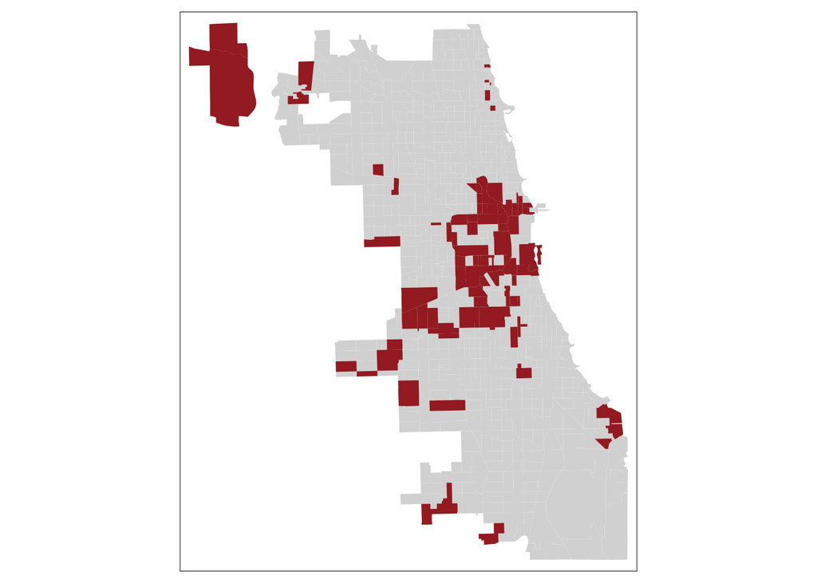

```r
tm_shape(chives) + tm_fill() +
  tm_shape(fewTrees) + tm_fill(col = "brown")
```

The subset of data that we have includes all of the original data. Let’s map social vulnerability measures for the `fewTrees` dataset. Higher SVI indicates higher vulnerability.

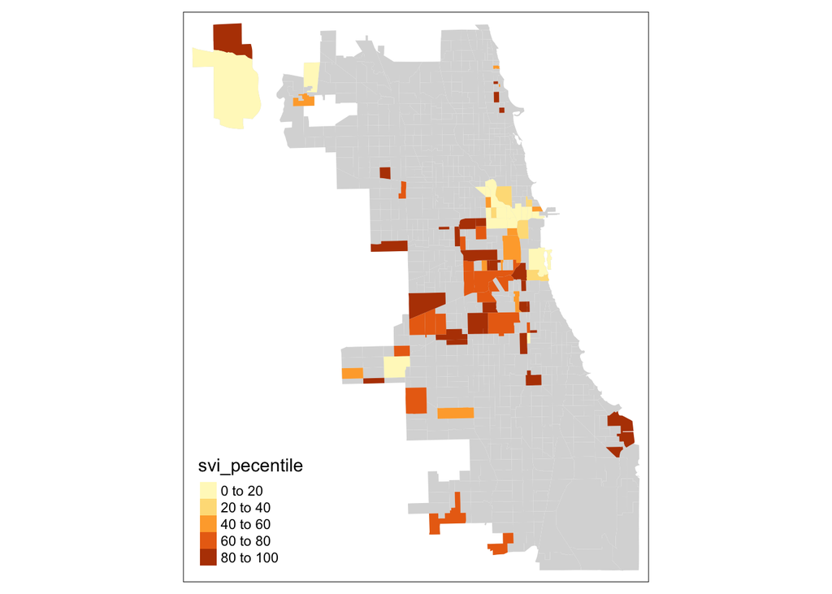

```r
tm_shape(chives) + tm_fill() +
  tm_shape(fewTrees) + tm_fill("svi_pecentile")
```

Let’s say we want to identify some key characteristics of areas without too many trees in the city. Using our same filter above (or whatever version you’d like to use), we can add an additional option. In the example below, we select all areas with <10% tree crown density that have high social vulnerability (ie. the social vulnerability index percentile is above 60%). Then, we map it.

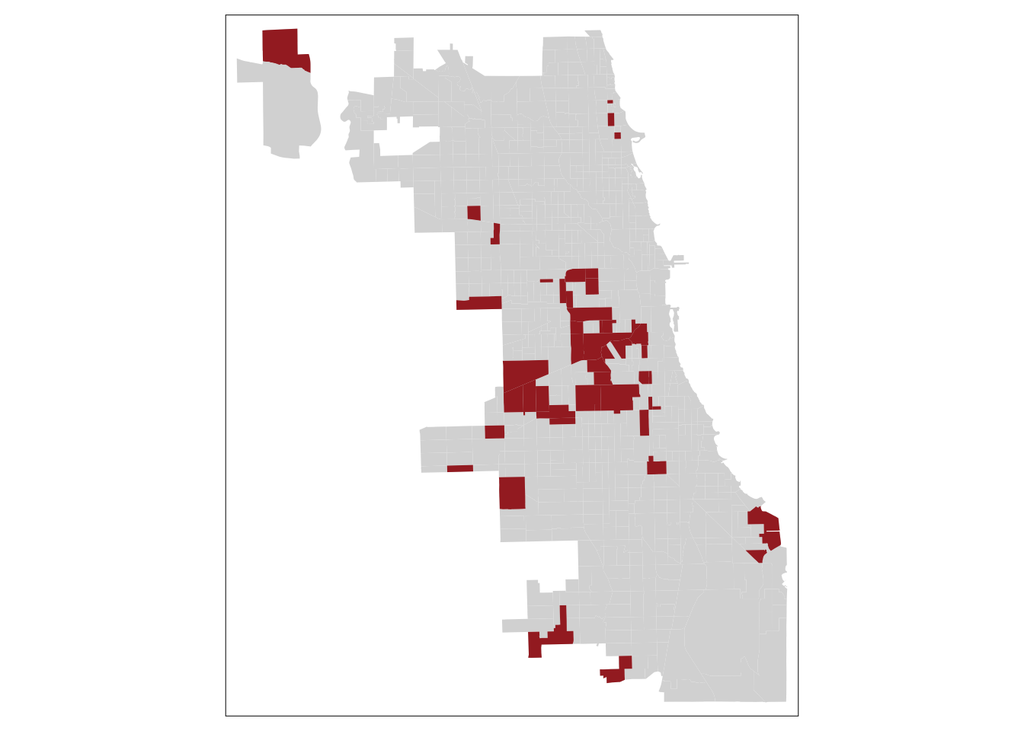

```r
fewTreesSVI <- chives %>%
  filter(trees_crown_den < 10 & svi_pecentile > 60)

tm_shape(chives) + tm_fill() +
  tm_shape(fewTreesSVI) + tm_fill(col = "brown")
```

### Question 2

We can see that several tracts could be found in areas with fewer trees, and higher social vulnerability. Explore another paired query, choosing a new variable (instead of social vulnerability). You can explore the data on your own, read the metadata further on the original data website, etc. to identify a reasonable cutoff.

Generate and run the query (with 2 criteria).

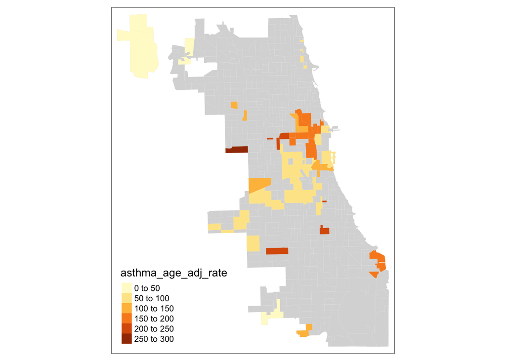

```r
# Trees area (trees_area) and prevalence of asthma (asthma_age_adj_rate)

tm_shape(chives) + tm_fill() +
  tm_shape(fewTrees) + tm_fill("asthma_age_adj_rate")
```

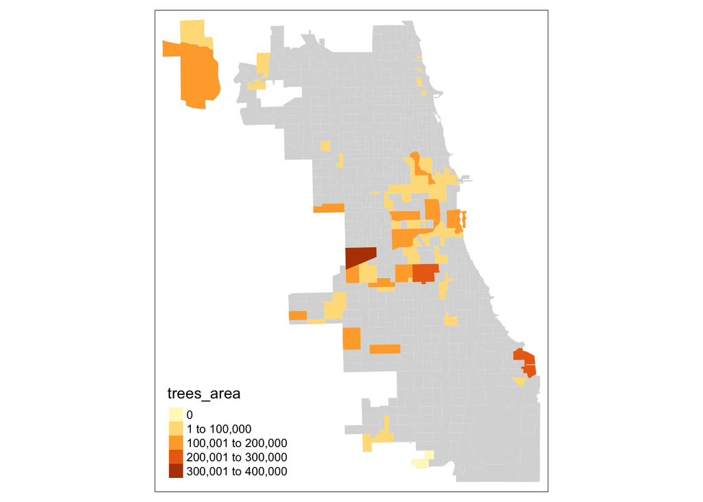

```r
tm_shape(chives) + tm_fill() +
  tm_shape(fewTrees) + tm_fill("trees_area")
```

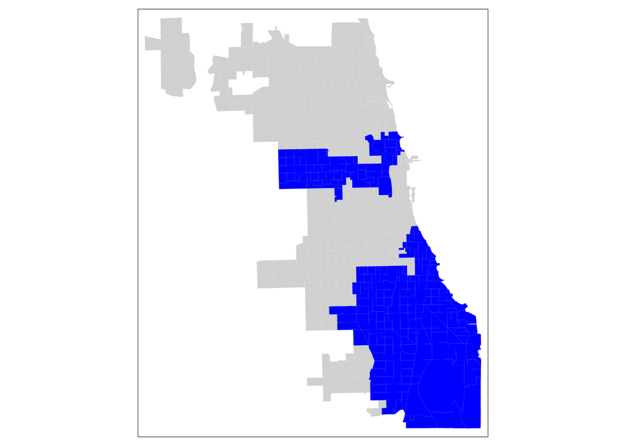

```r
highAsthma <- chives %>%
  filter(asthma_age_adj_rate > 150)

tm_shape(chives) + tm_fill() +
  tm_shape(highAsthma) + tm_fill(col = "blue")
```

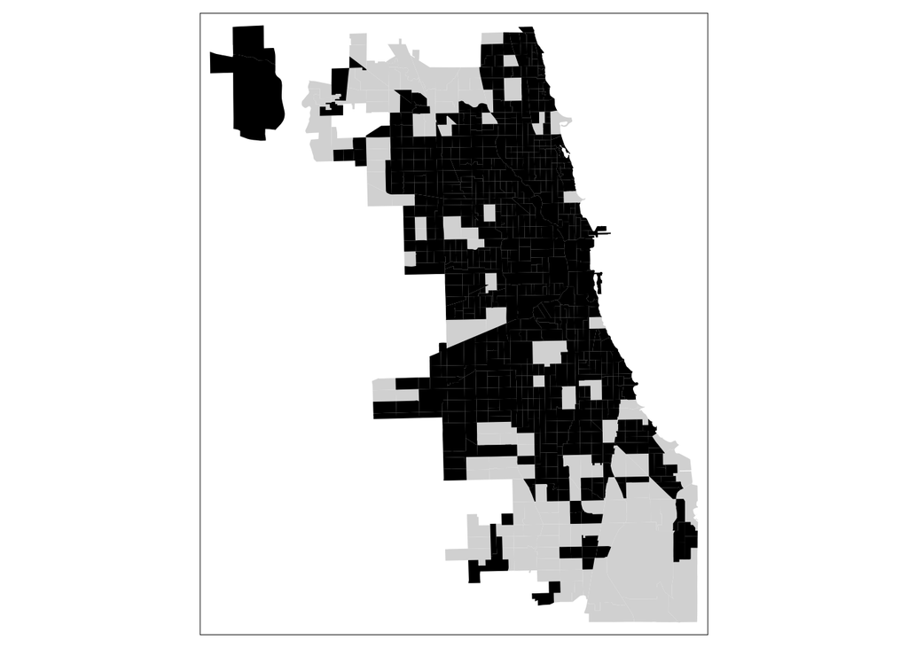

```r
lowTreeArea <- chives %>%
  filter(trees_area < 200000)

tm_shape(chives) + tm_fill() +
  tm_shape(lowTreeArea) + tm_fill(col = "black")
```

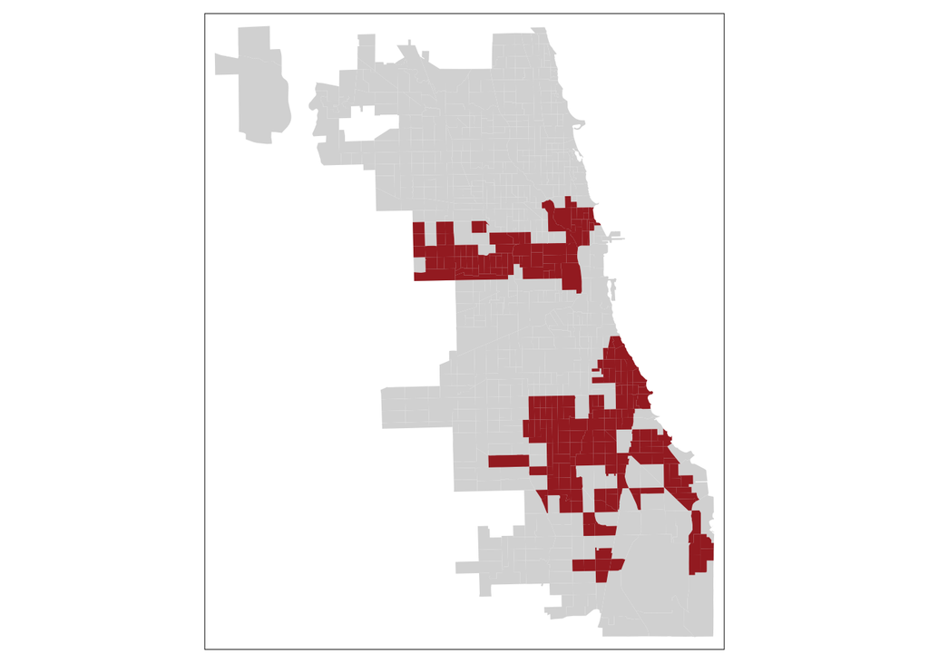

```r
lowTreeAreaAsthma <- chives %>%
  filter(trees_area < 200000 & asthma_age_adj_rate > 150)

tm_shape(chives) + tm_fill() +
  tm_shape(lowTreeAreaAsthma) + tm_fill(col = "brown")
```

### Question 3

Explain why you selected this query, and briefly describe any interesting patterns you discovered.

The reason why i selected these two queries was because I was always curious whether or not asthma or any lung disease would be affected by the amount of trees in a particular area. Since we already used the “trees_crown_den” key in the example, I decided on using the “trees_area” key and compared it with the asthma age adjusted rate (asthma_age_adj_rate).

Let’s take data wrangling a bit further and start to aggregate our dataset. We will use `group_by` and `summarise` functions from the `tidyverse` library we’re using. (Technically, they’re from the `dplyr` package within the `tidyverse`.)

`Group_by` tells the code which variable we should aggregate on. For example, let’s say we want to know how many trees exist in each community area in Chicago. We’ll (1) `group_by` the “community” field and (2) `summarise` using the total sum of trees. We’ll assign the total number of trees to equal a new variable, called “Trees”. We may also want to know how many tracts are included in each community, so are interested the total `n` of tracts. The code looks like this:

```r
treeCom <- chives %>%
  group_by(community) %>%
  summarize(Trees = sum(trees_n),
            TotTracts = n())

head(treeCom)
```

```
## Simple feature collection with 6 features and 3 fields
## Geometry type: POLYGON
## Dimension:     XY
## Bounding box:  xmin: -87.80623 ymin: 41.72865 xmax: -87.62886 ymax: 41.97595
## Geodetic CRS:  WGS 84
## # A tibble: 6 × 4
##   community      Trees TotTracts                                        geometry
##   <chr>          <int>     <int>                                   <POLYGON [°]>
## 1 ALBANY PARK    16496        11 ((-87.69782 41.9654, -87.69871 41.9662, -87.69…
## 2 ARCHER HEIGHTS  7794         5 ((-87.72337 41.80055, -87.72315 41.80055, -87.…
## 3 ARMOUR SQUARE   4866         5 ((-87.62978 41.83852, -87.62979 41.83926, -87.…
## 4 ASHBURN        30954         8 ((-87.72144 41.73486, -87.72142 41.73486, -87.…
## 5 AUBURN GRESHAM 28200        15 ((-87.63406 41.73594, -87.63406 41.73597, -87.…
## 6 AUSTIN         54572        24 ((-87.77536 41.902, -87.77535 41.90163, -87.77…
```

And we can map it!

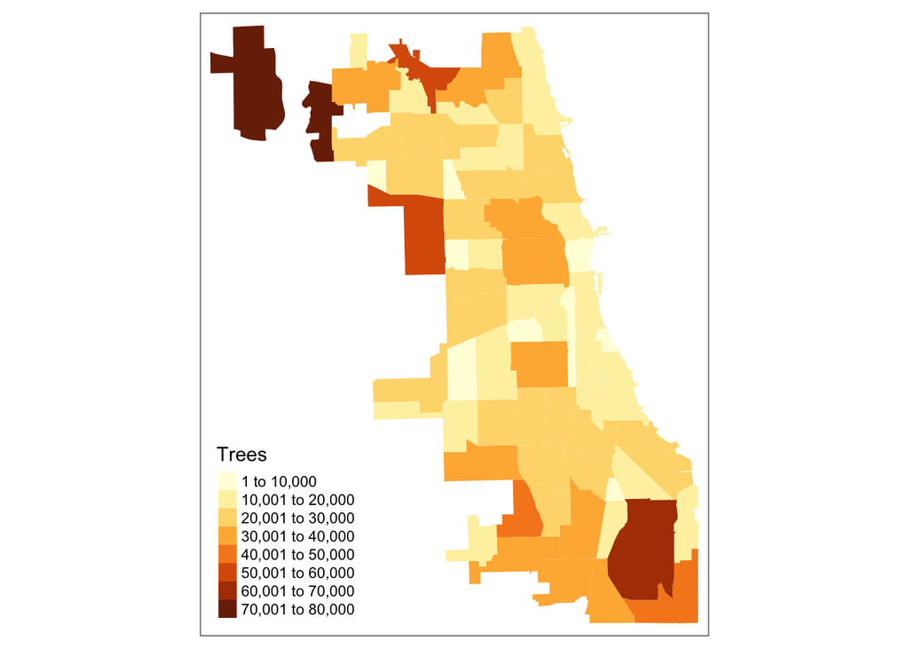

```r
tm_shape(treeCom) + tm_fill(col = "Trees")
```

Note that this dataset no longer shows tracts, since we’re actually working with *communities*. You can check the dimension of this data frame to be sure:

```r
dim(treeCom)
```

```
## [1] 77  4
```

### Question 4

Take this aggregation further. Add more to the code chunk above to generate a community area dataset that includes **at least five variables of interest**. Note that some variables you’ll need to sum (like total number of trees), whereas others will need to be averaged. You should use the variables included in the original *Chives* dataset.

Your code should also output a table view of the data.

```r
treeCom2 <- chives %>%
  group_by(community) %>%
  summarize(Trees = sum(trees_n, na.rm = TRUE),
            TotTracts = n(),
            AvgAsthmaRate = mean(asthma_age_adj_rate, na.rm = TRUE),
            AvgNDVI = mean(ndvi, na.rm = TRUE),
            AvgPopulation = mean(acs_population, na.rm = TRUE),
            AvgHardship = mean(hardship, na.rm = TRUE)
            )

head(treeCom2)
```

```
## Simple feature collection with 6 features and 7 fields
## Geometry type: POLYGON
## Dimension:     XY
## Bounding box:  xmin: -87.80623 ymin: 41.72865 xmax: -87.62886 ymax: 41.97595
## Geodetic CRS:  WGS 84
## # A tibble: 6 × 8
##   community      Trees TotTracts AvgAsthmaRate AvgNDVI AvgPopulation AvgHardship
##   <chr>          <int>     <int>         <dbl>   <dbl>         <dbl>       <dbl>
## 1 ALBANY PARK    16496        11          82.1   0.288         4577.        27.7
## 2 ARCHER HEIGHTS  7794         5          55.1   0.221         2616.        27.6
## 3 ARMOUR SQUARE   4866         5         102.    0.198         2744.        43.8
## 4 ASHBURN        30954         8         136.    0.340         5498.        22.3
## 5 AUBURN GRESHAM 28200        15         211.    0.337         3018.        30.2
## 6 AUSTIN         54572        24         221.    0.325         3948.        31.2
## # ℹ 1 more variable: geometry <POLYGON [°]>
```

**Pro Tip:** If there are null or NA variables in the census tracts, you won’t get a mean value in aggregate. To force an average when some areas may have values (and others remain NA/excluded) add `na.rm = TRUE`. For example: `mean(trees, na.rm=TRUE)`.

### Question 5

Generate three maps of three different variables at the community area level using `tmap`. You may get bonus points (up to 5pts total) for going above and beyond in working with thoughtful `tmap` parameters! Review the in-class tutorial from our first week for more ideas, and/or explore the online textbook we use for more ideas.

```
## Legend labels were too wide. The labels have been resized to 0.38, 0.35, 0.35, 0.35, 0.35. Increase legend.width (argument of tm_layout) to make the legend wider and therefore the labels larger.
```

```
## Legend labels were too wide. The labels have been resized to 0.42, 0.42, 0.38, 0.35, 0.35. Increase legend.width (argument of tm_layout) to make the legend wider and therefore the labels larger.
```

```
## Legend labels were too wide. The labels have been resized to 0.35, 0.35, 0.35, 0.35, 0.35. Increase legend.width (argument of tm_layout) to make the legend wider and therefore the labels larger.
```

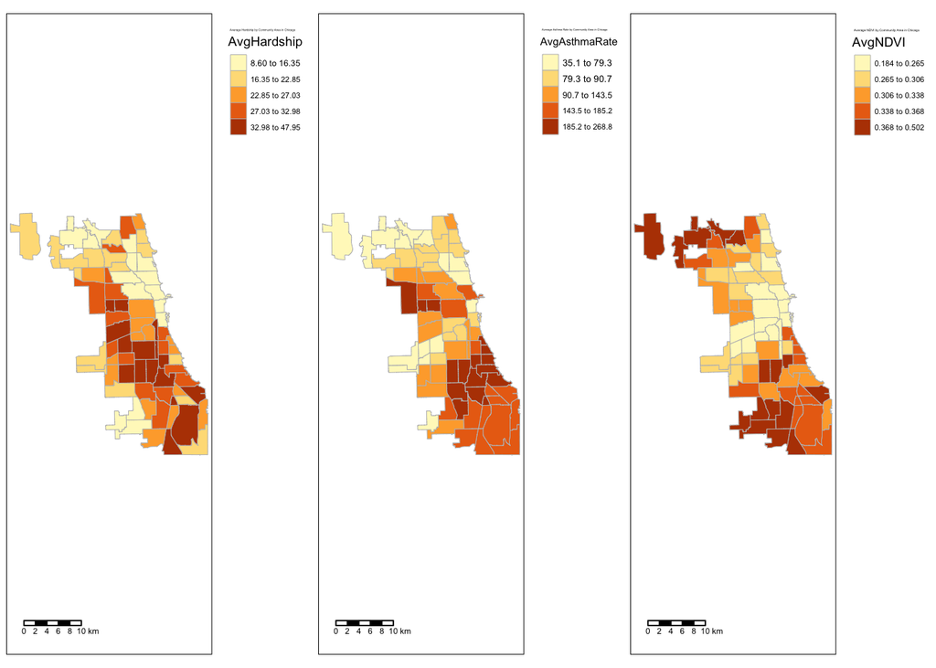

```r
# Map 1 (AvgHardship)
map1 <- tm_shape(treeCom2) +
  tm_fill(col = "AvgHardship", style = "quantile") +
  tm_borders(col = "gray", lwd = 0.5) +
  tm_legend(outside = TRUE) +
  tm_scale_bar(position = c("left", "bottom")) +
  tm_layout(
    title = "Average Hardship by Community Area in Chicago",
    legend.title.size = 0.7,
    legend.text.size = 0.6
  )

# Map 2 (AvgAsthmaRate)
map2 <- tm_shape(treeCom2) +
  tm_fill(col = "AvgAsthmaRate", style = "quantile") +
  tm_borders(col = "gray", lwd = 0.5) +
  tm_legend(outside = TRUE) +
  tm_scale_bar(position = c("left", "bottom")) +
  tm_layout(
    title = "Average Asthma Rate by Community Area in Chicago",
    legend.title.size = 0.7,
    legend.text.size = 0.6
  )

# Map 3 (AvgNVDI)
map3 <- tm_shape(treeCom2) +
  tm_fill(col = "AvgNDVI", style = "quantile") +
  tm_borders(col = "gray", lwd = 0.5) +
  tm_legend(outside = TRUE) +
  tm_scale_bar(position = c("left", "bottom")) +
  tm_layout(
    title = "Average NDVI by Community Area in Chicago",
    legend.title.size = 0.7,
    legend.text.size = 0.6
  )

tmap_arrange(map1, map2, map3)
```

### Question 6

What interesting trends did you find? Discuss in 1-2 paragraphs.

Render your document by clicking on the “Knit” option in RStudio. Upload the .html file to your assignment submission!

.